# Prose

## a cooperative text editor for you and your robot

A browser window for writing with an agent. Select a passage and say what's on your mind: “What does this mean?” “Too long.” “Keep the point, lose the throat-clearing.”

**Built from David Crespo’s Prose.** Find him [on Bluesky](https://bsky.app/profile/davidcrespo.bsky.social), or see what he’s building now in ah.

- [Get Prose](https://github.com/PropterMalone/xo-kit/releases/tag/xo-2026-11-13-prose-rc.3) Source download · preview release
- [Set it up with XO](https://github.com/PropterMalone/xo-kit/blob/51ec89a84ae117ac2374f88c0c53e1726a54218b/kit/flows/prose.md) Give the guide to your agent.

**Select & comment**

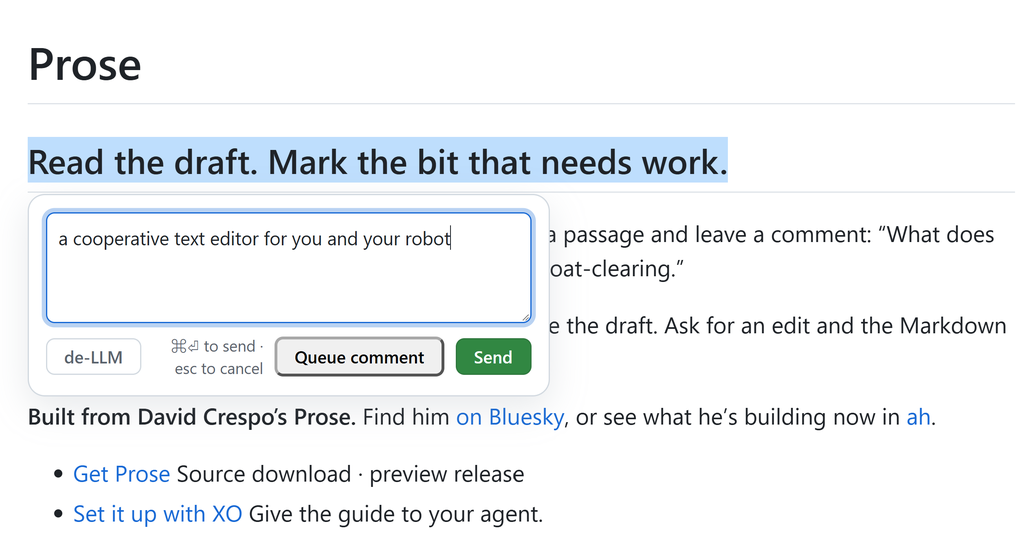

Select a passage and say what you want.

## Less copy-paste

You’re reading a letter. The second paragraph sounds like somebody trying to win an argument on LinkedIn. Highlight it and ask your robot to tone it down.

**de-LLM**

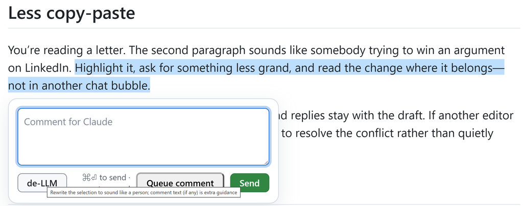

Let your robot take a crack at it.

## Direct Delete — RC3

Direct Delete is available in the RC3 source preview, not earlier packages. Select a passage and choose **Delete** to remove it directly from your Markdown file, with no model or connected agent. Undo with **Ctrl+Z** in the plain editor.

Prose refuses the deletion if the selection is ambiguous or stale, or the plain editor has unsaved changes. Your current file is authoritative: if you change or undo the deletion, do not ask the agent to reapply it.

## Getting started

Prose is part of xo, but you don’t need the rest of xo to use it.

You’ll need **Deno 2.9.6** and, for agent replies, a compatible Claude Code or Codex session. The [agent guide](https://github.com/PropterMalone/xo-kit/blob/51ec89a84ae117ac2374f88c0c53e1726a54218b/kit/flows/prose.md) covers the download and launch commands.

**Windows + Claude:** the tested route needs `--allow-windows-claude-all-access`. It disables Deno’s permission sandbox, giving the process broad access to files, programs and the network. Use it only if you’re comfortable trusting Prose with that access. The default launcher does not enable it.

**Mac:** prior RC1 editor and browser checks passed; the changed RC3 runtime has not been run natively on macOS.

Text read by a cloud agent goes to its provider. Keep the local session URL private and stop the server when you’re done.

**Download checks and testing notes**

Version **0.1.0-rc.3**: [source ZIP](https://github.com/PropterMalone/xo-kit/releases/download/xo-2026-11-13-prose-rc.3/prose-0.1.0-rc.3-source.zip) · [checksum file](https://github.com/PropterMalone/xo-kit/releases/download/xo-2026-11-13-prose-rc.3/prose-0.1.0-rc.3-source.zip.sha256)

RC3 source ZIP: **4,139,722 bytes**. Native RC3 Windows and macOS checks have not been run. Prior RC1 platform observations and RC2 Linux/synthetic browser checks are historical, not RC3 recertification. Local extracted-archive direct Delete browser checks are not real-model/agent end-to-end acceptance.

SHA256: `6a3b5ee15110f24e13316b317c3c3b8a95888198ec987bb55a0bcb167c0d8f91`

For the prior RC1 runtime, the Windows x64 Claude workflow was checked with Claude Code 2.1.316, Deno 2.9.6 and Edge. Mac ARM64 runtime/browser checks used simulated agent replies; Mac real-agent handling remains unverified. A cached Linux Codex workflow was checked separately.

Fresh installation, interrupted-agent recovery, general resend/deduplication, Intel Macs, Windows ARM64 and other browsers remain unverified. This is a source download, not an installer or offline bundle. GitHub’s automatic repository downloads contain the xo guide, not the attached Prose runtime.

## Thanks, David!

This version comes from David Crespo’s [original standalone Prose](https://github.com/david-crespo/dotfiles/tree/31262f3d8506ede2d10004cd5c4a21d076541848), with selected code and ideas from [ah](https://github.com/david-crespo/ah/tree/208c7a1b40c1ba464531196c96542c5ae99ba07e). Our changes are maintained separately; they don’t imply his endorsement.

Both MIT notices are included with the download: [Copyright 2024 David Crespo](https://raw.githubusercontent.com/david-crespo/dotfiles/31262f3d8506ede2d10004cd5c4a21d076541848/LICENSE) and [Copyright 2026 David Crespo](https://raw.githubusercontent.com/david-crespo/ah/208c7a1b40c1ba464531196c96542c5ae99ba07e/LICENSE), along with the third-party notices.

Back to xo